# InsightNet Case Study: Forecasting COVID deaths

2024-08-31

# Packages and data

```r
library(tidyverse)
library(tidymodels)
library(epidatasets)
library(epidatr)
library(epiprocess)
library(epipredict)

#set_cache(cache_dir = 'epi_cache', days = 30)
theme_set(theme_bw())
```

Download finalized COVID cases and deaths for California.

```r
cases <- pub_covidcast(
  source = "jhu-csse",
  signals = "confirmed_incidence_num",
  time_type = "day",
  geo_type = "state",
  time_values = epirange(20200401, 20220101),
  geo_values = "ca") %>%
  select(geo_value, time_value, cases = value)

deaths <- pub_covidcast(
  source = "jhu-csse",
  signals = "deaths_incidence_num",
  time_type = "day",
  geo_type = "state",
  time_values = epirange(20200401, 20220101),
  geo_values = "ca") %>%
  select(geo_value, time_value, deaths = value)
```

# Pre-process and visualize data

Join the dataframes and create `epi_df`.

```r
ca <- left_join(cases, deaths, by = c("time_value", "geo_value")) %>%
  as_epi_df()

ca
```

```
## An `epi_df` object, 641 x 4 with metadata:
## * geo_type  = state
## * time_type = day
## * as_of     = 2024-09-25 17:58:33.439046
##
## # A tibble: 641 × 4
##    geo_value time_value cases deaths
##  * <chr>     <date>     <dbl>  <dbl>
##  1 ca        2020-04-01  1254     29
##  2 ca        2020-04-02  1499     37
##  3 ca        2020-04-03  1324     40
##  4 ca        2020-04-04   746     17
##  5 ca        2020-04-05  1655     50
##  6 ca        2020-04-06  1510     28
##  7 ca        2020-04-07  1097     53
##  8 ca        2020-04-08  1480     63
##  9 ca        2020-04-09   960     52
## 10 ca        2020-04-10  1216     38
## # ℹ 631 more rows
```

Scale cases and deaths by population. State population data is available inside `{epipredict}` as `state_census`.

```r
ca <- left_join(
  x = ca,
  y = state_census %>% select(pop, abbr),
  by = c("geo_value" = "abbr"))

ca <- ca %>%
  mutate(cases = cases / pop * 1e5, # cases / 100K
         deaths = deaths / pop * 1e5) %>% # deaths / 100K
  select(-pop)
```

Now, use `epi_slide()`, to calculate trailing 7 day averages of cases and deaths.

```r
ca <- ca %>%
  epi_slide(cases = mean(cases), before = 6) %>%
  epi_slide(deaths = mean(deaths), before = 6)
```

Visualize the data.

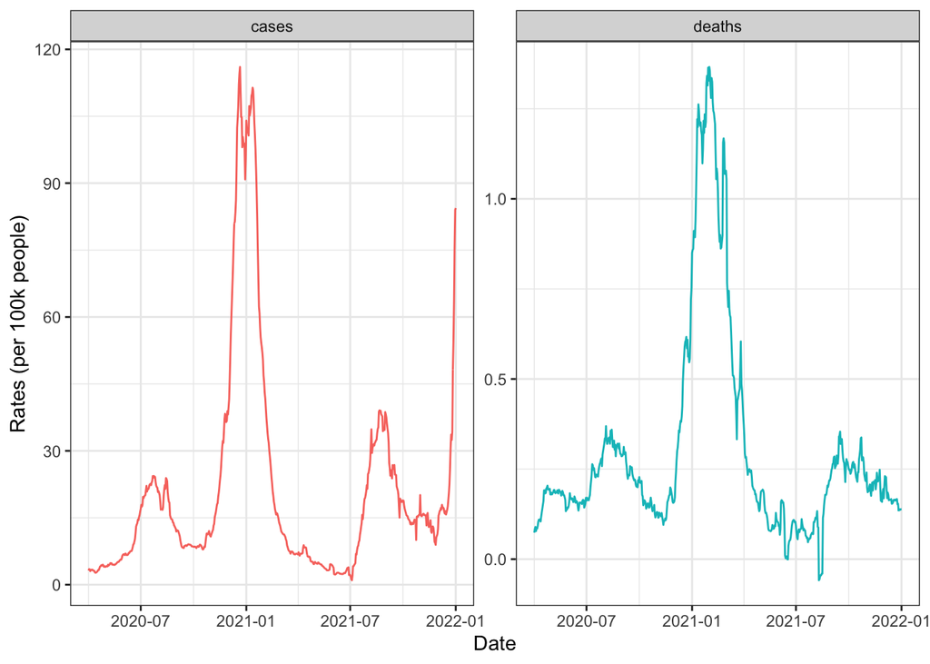

```r
ca %>%
  pivot_longer(cols = c(cases, deaths), names_to = 'Signal') %>%
  ggplot(aes(time_value, value, col = Signal)) +
  geom_line() +
  xlab('Date') +
  ylab('Rates (per 100k people)') +
  facet_wrap(~Signal, scales = 'free') +
  theme(legend.position = "none")
```

Notice that some of the COVID death rates are below 0. Let’s impute these values to be 0.

```r
ca$deaths[ca$deaths < 0] <- 0
```

Overlay cases and deaths on the same plot.

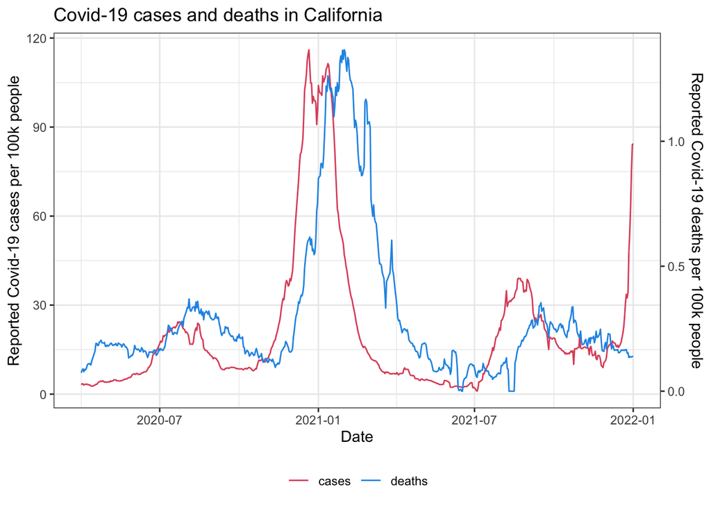

```r
# Handy function to produce a transformation from one range to another
trans = function(x, from_range, to_range) {
  (x - from_range[1]) / (from_range[2] - from_range[1]) *
    (to_range[2] - to_range[1]) + to_range[1]
}

# Compute ranges of the two signals, and transformations in b/w them
range1 = ca %>% select(cases) %>% range()
range2 = ca %>% select(deaths) %>% range()
trans12 = function(x) trans(x, range1, range2)
trans21 = function(x) trans(x, range2, range1)

ggplot(ca %>%
         mutate(deaths = trans21(deaths)) %>%
         pivot_longer(cols = c(cases, deaths), names_to = 'name'),
       aes(x = time_value, y = value)) +
  geom_line(aes(color = name)) +
  scale_color_manual(values = palette()[c(2,4)]) +
  scale_y_continuous(
    name = "Reported Covid-19 cases per 100k people",
    limits = range1,
    sec.axis = sec_axis(
      trans = trans12,
      name = "Reported Covid-19 deaths per 100k people")) +
  labs(title = "Covid-19 cases and deaths in California", x = "Date") +
  theme(legend.position = "bottom", legend.title = element_blank())
```

Split data into training (before 2021-03-01) and testing set (after 2021-03-01).

```r
t0_date <- as.Date('2021-03-01')

train <- ca %>% filter(time_value <= t0_date)
test <- ca %>% filter(time_value > t0_date)

t0 <- nrow(train)
```

# Choose and create lagged predictor

Check which lag leads to highest correlation between cases and deaths on the training set.

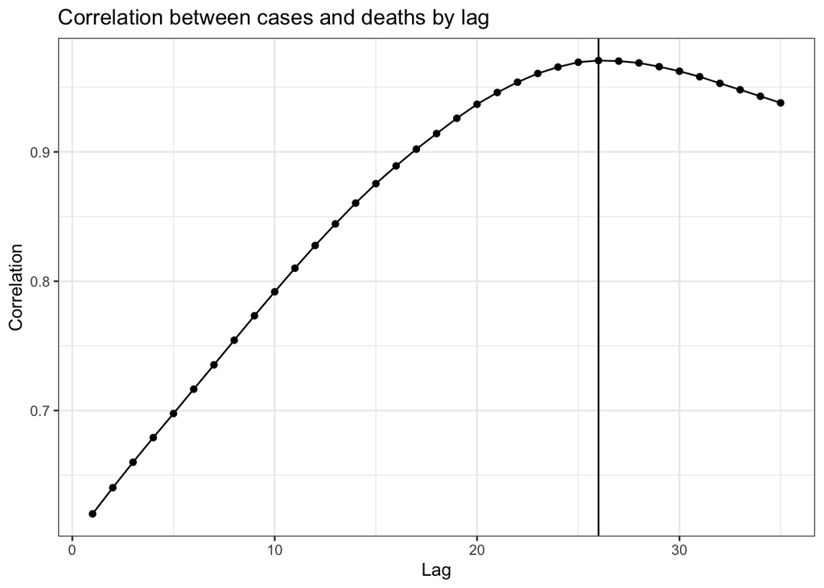

```r
# look at cases and deaths (where we move deaths forward by 1, 2, ..., 35 days)
lags = 1:35
cor_deaths_cases <- lapply(lags,
                             function(x) epi_cor(train, deaths, cases,
                                                 cor_by = geo_value, dt1 = x))

cor_deaths_cases <- list_rbind(cor_deaths_cases, names_to = 'Lag')

# best lag
k <- which.max(cor_deaths_cases$cor)

cor_deaths_cases %>%
  ggplot(aes(Lag, cor)) +
  geom_point() +
  geom_line() +
  labs(x = "Lag", y = "Correlation") +
  geom_vline(xintercept = k) +
  ggtitle('Correlation between cases and deaths by lag')
```

We will use lagged COVID cases to predict COVID deaths. COVID cases will be lagged by 26.

```r
ca$lagged_cases <- dplyr::lag(ca$cases, n = k)
train <- ca %>% filter(time_value <= t0_date)
test <- ca %>% filter(time_value > t0_date)
```

Let’s plot COVID deaths versus lagged COVID cases to check that the relationship is approximately linear.

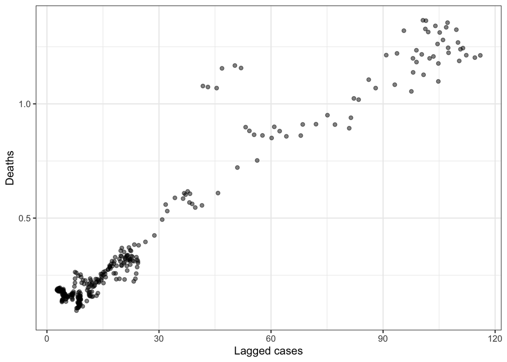

```r
ggplot(train, aes(lagged_cases, deaths)) +
  geom_point(alpha = .5) +
  labs(x = "Lagged cases", y = "Deaths")
```

# Lagged linear regression

Perform linear regression of deaths on lagged cases using training data.

```r
reg_lagged = lm(deaths ~ lagged_cases, data = train)
coef(reg_lagged)
```

```
##  (Intercept) lagged_cases
##   0.09533276   0.01134891
```

Plot again COVID deaths versus lagged COVID cases with regression line.

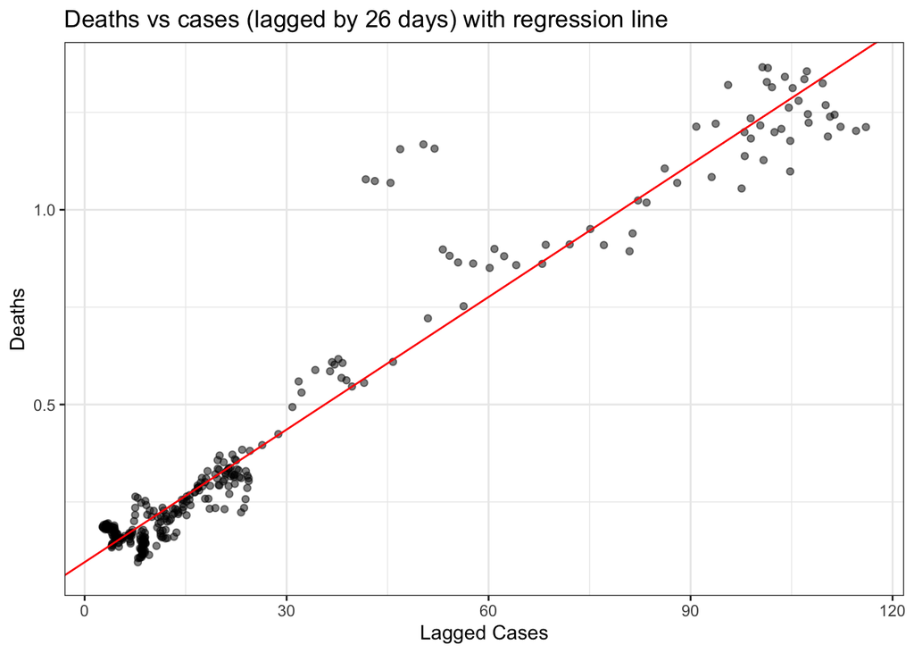

```r
ggplot(train, aes(lagged_cases, deaths)) +
  geom_point(alpha = .5) +
  geom_abline(intercept = coef(reg_lagged)[1], slope = coef(reg_lagged)[2],
              col = 'red') +
  labs(x = "Lagged Cases", y = "Deaths") +
  ggtitle("Deaths vs cases (lagged by 26 days) with regression line")
```

## Training error

Let’s compute the MSE, MAE, MAPE, and MASE on the training set.

```r
pred_train <- predict(reg_lagged)
train$pred_train <- c(rep(NA, k), pred_train)

training_mse <- mean((train$deaths - train$pred_train)^2, na.rm = T)
training_mae <- mean(abs(train$deaths - train$pred_train), na.rm = T)
training_mape <- 100 * mean(abs(train$deaths - train$pred_train) / train$deaths,
                     na.rm = T)
training_mase <- 100 * training_mae / mean(abs(diff(train$deaths[-c(1:k)])))

errors <- data.frame("MSE" = training_mse, "MAE"= training_mae,
                     "MAPE" = training_mape, "MASE" = training_mase,
                     row.names = "training")
errors
```

```
##                  MSE        MAE     MAPE     MASE
## training 0.008094702 0.05294347 17.82704 311.8417
```

The predictions on the training set track the observed death rates quite closely.

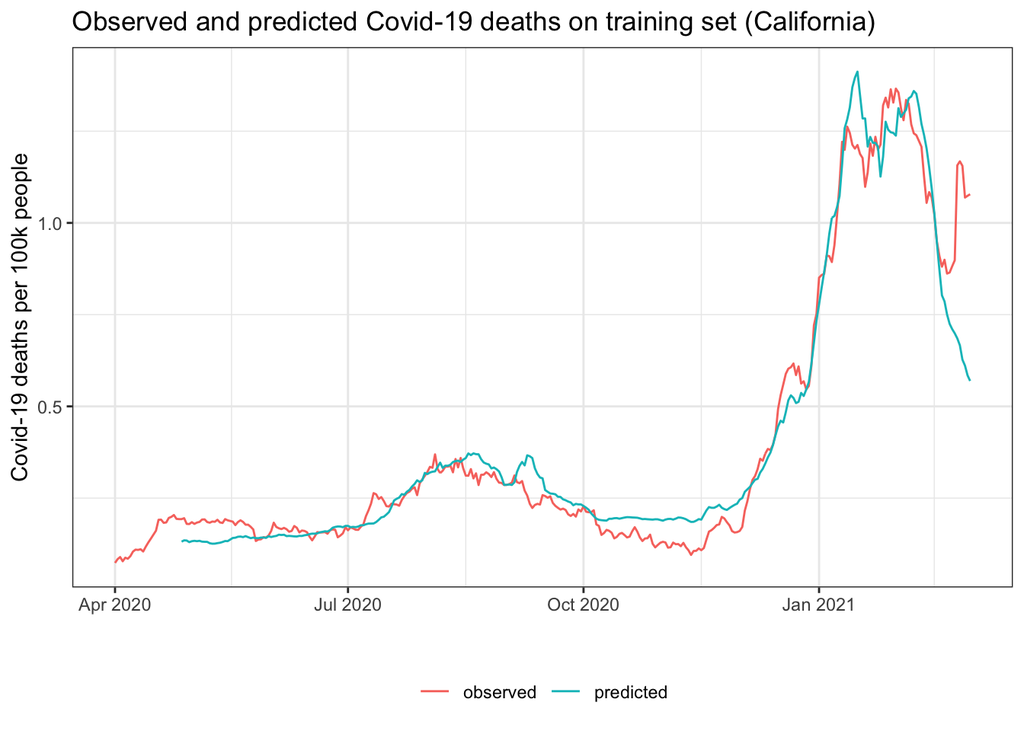

```r
train %>%
  mutate(observed = deaths, predicted = pred_train) %>%
  pivot_longer(cols = c(predicted, observed), names_to = 'Deaths') %>%
  ggplot(aes(time_value, value, col = Deaths)) +
  geom_line() +
  labs(title = "Observed and predicted Covid-19 deaths on training set (California)",
       x = "", y = "Covid-19 deaths per 100k people") +
  theme(legend.position = "bottom", legend.title = element_blank())
```

## Split-sample error

Let’s compute the MSE, MAE, MAPE, and MASE on the test set. As expected, the errors on the test set are much larger than the errors on the training set.

Notice that the MAPE does not have a finite value because there are some 0s in the denominator.

```r
test$pred_test <- predict(reg_lagged, newdata = test)
test_mse <- mean((test$deaths - test$pred_test)^2)
test_mae <- mean(abs(test$deaths - test$pred_test))
test_mape <- 100 * mean(abs(test$deaths - test$pred_test) / test$deaths)
test_mase <- 100 * test_mae / mean(abs(diff(test$deaths)))

errors <- rbind(errors,
                data.frame("MSE" = test_mse, "MAE"= test_mae,
                           "MAPE" = test_mape, "MASE" = test_mase,
                           row.names = "split-sample"))
errors
```

```
##                      MSE        MAE     MAPE     MASE
## training     0.008094702 0.05294347 17.82704 311.8417
## split-sample 0.016062115 0.10175475      Inf 671.1406
```

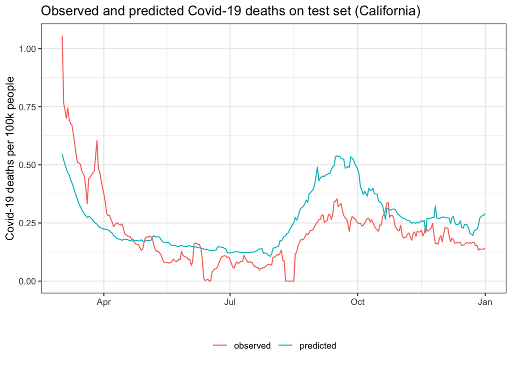

```r
test %>%
  mutate(observed = deaths, predicted = pred_test) %>%
  pivot_longer(cols = c(predicted, observed), names_to = 'Deaths') %>%
  ggplot(aes(time_value, value, col = Deaths)) +
  geom_line() +
  labs(title = "Observed and predicted Covid-19 deaths on test set (California)",
       x = "", y = "Covid-19 deaths per 100k people") +
  theme(legend.position = "bottom", legend.title = element_blank())
```

Can we perform split-sample using `{epipredict}`?

`arx_forecaster` allows to fit the same model using the training data, but does it provide a way to obtain the training error and the split-sample error?

```r
head(test)
```

```
## An `epi_df` object, 6 x 6 with metadata:
## * geo_type  = state
## * time_type = day
## * as_of     = 2024-09-25 17:58:33.439046
##
## # A tibble: 6 × 6
##   geo_value time_value cases deaths lagged_cases pred_test
## * <chr>     <date>     <dbl>  <dbl>        <dbl>     <dbl>
## 1 ca        2021-03-02  12.5  1.06          39.6     0.545
## 2 ca        2021-03-03  11.9  0.767         37.5     0.520
## 3 ca        2021-03-04  11.7  0.733         35.8     0.501
## 4 ca        2021-03-05  11.5  0.700         34.0     0.482
## 5 ca        2021-03-06  11.3  0.745         32.7     0.466
## 6 ca        2021-03-07  11.3  0.694         31.8     0.457
```

```r
arx_forecaster(epi_data = train %>% as_epi_df(),
               outcome = "deaths",
               predictors = "cases",
               trainer = linear_reg() %>% set_engine("lm"),
               args_list = arx_args_list(lags = k-1, ahead = 1L))$predictions
```

```
## # A tibble: 1 × 5
##   geo_value .pred        .pred_distn forecast_date target_date
##   <chr>     <dbl>             <dist> <date>        <date>
## 1 ca        0.545 quantiles(0.55)[2] 2021-03-01    2021-03-02
```

## Time-series cross-validation

We will now perform time-series cross-validation fitting the model on:

- all the past data up to the forecasting time
- a trailing window of data up to the forecasting time

We set the trailing window to have size = 30, and we perform 1-step-ahead predictions.

```r
n <- nrow(ca)
pred_all_past = pred_trailing <- rep(NA, length = n - t0)
w <- 30 # trailing window size

for (t in (t0+1):n) {
  reg_all_past = lm(deaths ~ lagged_cases, data = ca,
                    #subset = (1:n) <= (t-k))
                    subset = (1:n) <= (t-1))
  reg_trailing = lm(deaths ~ lagged_cases, data = ca,
                    #subset = (1:n) <= (t-k) & (1:n) > (t-k-w))
                    subset = (1:n) <= (t-1) & (1:n) > (t-1-w))
  pred_all_past[t-t0] = predict(reg_all_past, newdata = data.frame(ca[t, ]))
  pred_trailing[t-t0] = predict(reg_trailing, newdata = data.frame(ca[t, ]))
}

test$pred_cv <- pred_all_past
test$pred_trailing_cv <- pred_trailing
```

We compute the cross-validated error when using all the past data up to the forecasting time. Since we are refitting the model as new data come in, the error (under all metrics) is slightly smaller than when using a split-sample approach, but is still not as small as when we compute it on the training data.

```r
cv_mse <- mean((test$deaths - pred_all_past)^2)
cv_mae <- mean(abs(test$deaths - pred_all_past))
cv_mape <- 100 * mean(abs(test$deaths - pred_all_past) / test$deaths)
cv_mase <- 100 * cv_mae / mean(abs(diff(test$deaths)))

errors <- rbind(errors,
                data.frame("MSE" = cv_mse, "MAE"= cv_mae,
                           "MAPE" = cv_mape, "MASE" = cv_mase,
                           row.names = "time series CV"))
errors
```

```
##                        MSE        MAE     MAPE     MASE
## training       0.008094702 0.05294347 17.82704 311.8417
## split-sample   0.016062115 0.10175475      Inf 671.1406
## time series CV 0.014838552 0.09623533      Inf 634.7363
```

```r
cv_trailing_mse <- mean((test$deaths - pred_trailing)^2)
cv_trailing_mae <- mean(abs(test$deaths - pred_trailing))
cv_trailing_mape <- 100 * mean(abs(test$deaths - pred_trailing) / test$deaths)
cv_trailing_mase <- 100 * cv_trailing_mae / mean(abs(diff(test$deaths)))

errors <- rbind(errors,
                data.frame("MSE" = cv_trailing_mse, "MAE"= cv_trailing_mae,
                           "MAPE" = cv_trailing_mape, "MASE" = cv_trailing_mase,
                           row.names = "time series CV + trailing"))
errors
```

```
##                                   MSE        MAE     MAPE     MASE
## training                  0.008094702 0.05294347 17.82704 311.8417
## split-sample              0.016062115 0.10175475      Inf 671.1406
## time series CV            0.014838552 0.09623533      Inf 634.7363
## time series CV + trailing 0.004064001 0.04507775      Inf 297.3179
```

We plot the 1-step-ahead predictions obtained by the model fitted on all past data and on trailing windows. The latter tracks the observed deaths quite well.

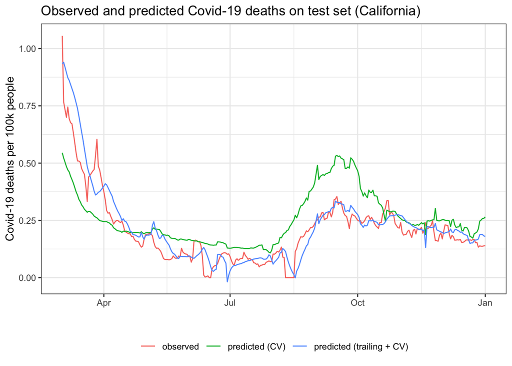

```r
test %>%
  mutate(observed = deaths,
         `predicted (CV)` = pred_cv,
         `predicted (trailing + CV)` = pred_trailing_cv) %>%
  pivot_longer(cols = c(observed, `predicted (CV)`, `predicted (trailing + CV)`),
               names_to = 'Deaths') %>%
  ggplot(aes(time_value, value, col = Deaths)) +
  geom_line() +
  labs(title = "Observed and predicted Covid-19 deaths on test set (California)",
       x = "", y = "Covid-19 deaths per 100k people") +
  theme(legend.position = "bottom", legend.title = element_blank())
```

The predictions we obtained by manually lagging `cases` and using `lm` within `for` loops can be equivalently obtained via `{epipredict}`. The latter gives a more user-friendly and straightforward way to obtain the predictions.

The approach with trailing window is reported next.

```r
# specify the forecast dates
fc_time_values <- seq(
  from = as.Date("2021-03-01"),
  to = as.Date("2021-12-30"),
  by = "1 day"
)

# slide an arx_forecaster with appropriate outcome, predictions, lags,
# and trailing window
epi_pred_cv_trailing <- epi_slide(
  ca,
  ~ arx_forecaster(epi_data = .x,
                   outcome = "deaths",
                   predictors = "cases",
                   trainer = linear_reg() %>% set_engine("lm"),
                   args_list = arx_args_list(lags = k-1, ahead = 1L)
                   )$predictions,
  # notice that `before` is not simply equal to w-1. That's because previously,
  # when considering a window from t to t+w, we had access to y_t, ..., y_{t+w}
  # and also to x_{t-k}, ..., x_{t+w-k}. (That's because of how we structured
  # the dataframe after manually lagging x.) So we were cheating by saying that
  # the trailing window had length w, as its actual size was w+k!
  before = (w+k-1),
  ref_time_values = fc_time_values,
  new_col_name = "fc"
)

# they match exactly
head(epi_pred_cv_trailing %>% select(fc_.pred, fc_target_date))
```

```
## # A tibble: 6 × 2
##   fc_.pred fc_target_date
##      <dbl> <date>
## 1    0.934 2021-03-02
## 2    0.940 2021-03-03
## 3    0.919 2021-03-04
## 4    0.895 2021-03-05
## 5    0.873 2021-03-06
## 6    0.861 2021-03-07
```

```r
head(test %>% select(pred_trailing_cv, time_value))
```

```
## # A tibble: 6 × 2
##   pred_trailing_cv time_value
##              <dbl> <date>
## 1            0.934 2021-03-02
## 2            0.940 2021-03-03
## 3            0.919 2021-03-04
## 4            0.895 2021-03-05
## 5            0.873 2021-03-06
## 6            0.861 2021-03-07
```

The method fitting on all past data up to the forecasting date can be implemented by changing `before = Inf` in `epi_slide`.

```r
# slide an arx_forecaster with appropriate outcome, predictions and lags
epi_pred_cv <- epi_slide(
  ca,
  ~ arx_forecaster(epi_data = .x,
                   outcome = "deaths",
                   predictors = "cases",
                   trainer = linear_reg() %>% set_engine("lm"),
                   args_list = arx_args_list(lags = k-1, ahead = 1L)
                   )$predictions,
  before = Inf,
  ref_time_values = fc_time_values,
  new_col_name = "fc"
)

# they match exactly
head(epi_pred_cv %>% select(fc_.pred, fc_target_date))
```

```
## # A tibble: 6 × 2
##   fc_.pred fc_target_date
##      <dbl> <date>
## 1    0.545 2021-03-02
## 2    0.522 2021-03-03
## 3    0.504 2021-03-04
## 4    0.485 2021-03-05
## 5    0.470 2021-03-06
## 6    0.461 2021-03-07
```

```r
head(test %>% select(pred_cv, time_value))
```

```
## # A tibble: 6 × 2
##   pred_cv time_value
##     <dbl> <date>
## 1   0.545 2021-03-02
## 2   0.522 2021-03-03
## 3   0.504 2021-03-04
## 4   0.485 2021-03-05
## 5   0.470 2021-03-06
## 6   0.461 2021-03-07
```

# AR model

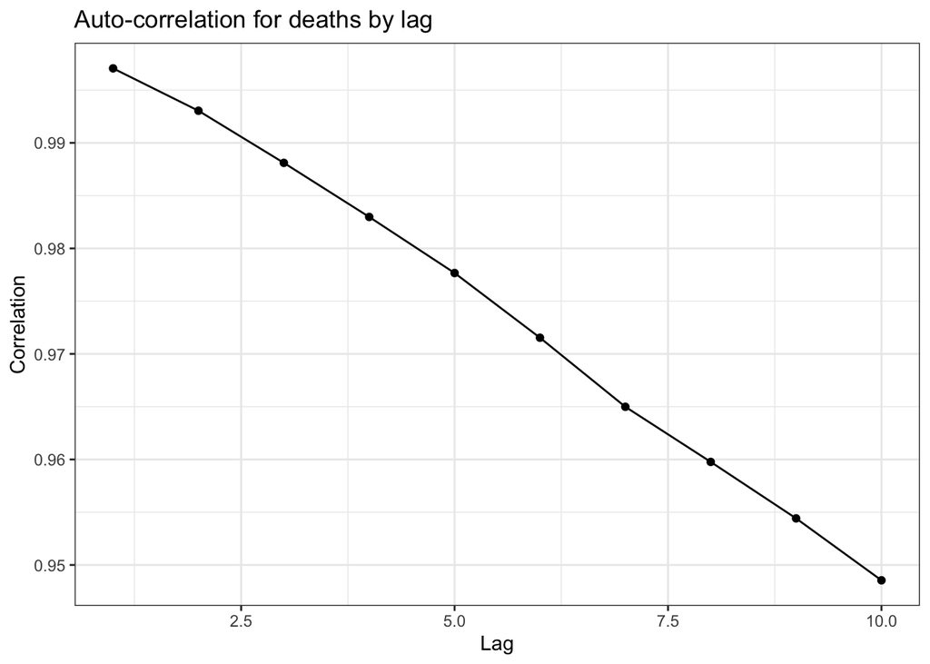

```r
lags <- 1:10
auto_cor_deaths <- lapply(lags,
                          function(x) epi_cor(train, deaths, deaths,
                                              cor_by = geo_value, dt1 = x))

auto_cor_deaths <- list_rbind(auto_cor_deaths, names_to = 'Lag')

auto_cor_deaths %>%
  ggplot(aes(Lag, cor)) +
  geom_point() +
  geom_line() +
  labs(x = "Lag", y = "Correlation") +
  ggtitle('Auto-correlation for deaths by lag')
```

```r
ca$deaths_lag_1 <- dplyr::lag(ca$deaths, n = 1)
ca$deaths_lag_2 <- dplyr::lag(ca$deaths, n = 2)
ca$deaths_lag_3 <- dplyr::lag(ca$deaths, n = 3)
```

```r
train <- ca %>% filter(time_value <= t0_date)
test <- ca %>% filter(time_value > t0_date)
```

Perform linear regression of deaths on lagged deaths using training data.

```r
reg_ar = lm(deaths ~ deaths_lag_1 + deaths_lag_2 + deaths_lag_3, data = train)
coef(reg_ar)
```

```
##  (Intercept) deaths_lag_1 deaths_lag_2 deaths_lag_3
##  0.002450969  1.156571154 -0.035465660 -0.121899526
```

# Next

- Fit AR using epi-slide, check if error goes down
- Fit ARX using epi-slide and including lagged cases and deaths as predictors, check if error goes down
- Is there an automatic way to select best lags within epipredict (e.g. using Lasso somehow)?
- Introduce probabilistic forecasters (quantile regression) and appropriate evaluation methods